# eda

## 🌡️ Predicción de la Temperatura del Aire

Comparación y Optimización de Modelos de Series de Tiempo y Aprendizaje Automático

📌 Descripción del Proyecto

Este proyecto analiza diferentes estrategias para predecir la temperatura del aire a partir de datos meteorológicos registrados por la estación del Instituto Max Planck de Bioquímica en Jena, Alemania.

Se busca responder: ¿Cuál es la estrategia más precisa y eficiente para predecir la temperatura del aire: modelos de series de tiempo que capturan autocorrelaciones o modelos de regresión basados en variables climáticas?

También se explora la posibilidad de desarrollar un modelo mejorado que combine ambos enfoques: series de tiempo + aprendizaje automático.

📊 Conjunto de Datos Nombre: Jena Climate Periodo: 2009-01-01 a 2016-12-31 Frecuencia: cada 10 minutos Variables: temperatura del aire, presión, humedad, dirección del viento, entre otras (14 en total)

## Agregamos librerias

```python
import pandas as pd
import numpy as np
import seaborn as sns
import matplotlib.pyplot as plt
```

## Cargamos los datos

```python
pd.set_option('display.float_format', lambda x: '%.3f' % x)
#Cargar datos
data = pd.read_csv("C:/Users/10Pearls/Documents/Proyecto final/datos/jena_climate_2009_2016.csv")
data.head()
```

|  | Date Time | p (mbar) | T (degC) | Tpot (K) | Tdew (degC) | rh (%) | VPmax (mbar) | VPact (mbar) | VPdef (mbar) | sh (g/kg) | H2OC (mmol/mol) | rho (g/m**3) | wv (m/s) | max. wv (m/s) | wd (deg) |
| --- | --- | --- | --- | --- | --- | --- | --- | --- | --- | --- | --- | --- | --- | --- | --- |
| 0 | 01.01.2009 00:10:00 | 996.520 | -8.020 | 265.400 | -8.900 | 93.300 | 3.330 | 3.110 | 0.220 | 1.940 | 3.120 | 1307.750 | 1.030 | 1.750 | 152.300 |
| 1 | 01.01.2009 00:20:00 | 996.570 | -8.410 | 265.010 | -9.280 | 93.400 | 3.230 | 3.020 | 0.210 | 1.890 | 3.030 | 1309.800 | 0.720 | 1.500 | 136.100 |
| 2 | 01.01.2009 00:30:00 | 996.530 | -8.510 | 264.910 | -9.310 | 93.900 | 3.210 | 3.010 | 0.200 | 1.880 | 3.020 | 1310.240 | 0.190 | 0.630 | 171.600 |
| 3 | 01.01.2009 00:40:00 | 996.510 | -8.310 | 265.120 | -9.070 | 94.200 | 3.260 | 3.070 | 0.190 | 1.920 | 3.080 | 1309.190 | 0.340 | 0.500 | 198.000 |
| 4 | 01.01.2009 00:50:00 | 996.510 | -8.270 | 265.150 | -9.040 | 94.100 | 3.270 | 3.080 | 0.190 | 1.920 | 3.090 | 1309.000 | 0.320 | 0.630 | 214.300 |

```python
# Dimensiones
print(f"Observaciones: {data.shape[0]}, Variables: {data.shape[1]}")
```

```
Observaciones: 420551, Variables: 15
```

```python
# Primeros y últimos valores
print("Primeros registros:")
display(data.head())

print("Últimos registros:")
display(data.tail())
```

```
Primeros registros:
```

|  | Date Time | p (mbar) | T (degC) | Tpot (K) | Tdew (degC) | rh (%) | VPmax (mbar) | VPact (mbar) | VPdef (mbar) | sh (g/kg) | H2OC (mmol/mol) | rho (g/m**3) | wv (m/s) | max. wv (m/s) | wd (deg) |
| --- | --- | --- | --- | --- | --- | --- | --- | --- | --- | --- | --- | --- | --- | --- | --- |
| 0 | 01.01.2009 00:10:00 | 996.520 | -8.020 | 265.400 | -8.900 | 93.300 | 3.330 | 3.110 | 0.220 | 1.940 | 3.120 | 1307.750 | 1.030 | 1.750 | 152.300 |
| 1 | 01.01.2009 00:20:00 | 996.570 | -8.410 | 265.010 | -9.280 | 93.400 | 3.230 | 3.020 | 0.210 | 1.890 | 3.030 | 1309.800 | 0.720 | 1.500 | 136.100 |
| 2 | 01.01.2009 00:30:00 | 996.530 | -8.510 | 264.910 | -9.310 | 93.900 | 3.210 | 3.010 | 0.200 | 1.880 | 3.020 | 1310.240 | 0.190 | 0.630 | 171.600 |
| 3 | 01.01.2009 00:40:00 | 996.510 | -8.310 | 265.120 | -9.070 | 94.200 | 3.260 | 3.070 | 0.190 | 1.920 | 3.080 | 1309.190 | 0.340 | 0.500 | 198.000 |
| 4 | 01.01.2009 00:50:00 | 996.510 | -8.270 | 265.150 | -9.040 | 94.100 | 3.270 | 3.080 | 0.190 | 1.920 | 3.090 | 1309.000 | 0.320 | 0.630 | 214.300 |

```
Últimos registros:
```

|  | Date Time | p (mbar) | T (degC) | Tpot (K) | Tdew (degC) | rh (%) | VPmax (mbar) | VPact (mbar) | VPdef (mbar) | sh (g/kg) | H2OC (mmol/mol) | rho (g/m**3) | wv (m/s) | max. wv (m/s) | wd (deg) |
| --- | --- | --- | --- | --- | --- | --- | --- | --- | --- | --- | --- | --- | --- | --- | --- |
| 420546 | 31.12.2016 23:20:00 | 1000.070 | -4.050 | 269.100 | -8.130 | 73.100 | 4.520 | 3.300 | 1.220 | 2.060 | 3.300 | 1292.980 | 0.670 | 1.520 | 240.000 |
| 420547 | 31.12.2016 23:30:00 | 999.930 | -3.350 | 269.810 | -8.060 | 69.710 | 4.770 | 3.320 | 1.440 | 2.070 | 3.320 | 1289.440 | 1.140 | 1.920 | 234.300 |
| 420548 | 31.12.2016 23:40:00 | 999.820 | -3.160 | 270.010 | -8.210 | 67.910 | 4.840 | 3.280 | 1.550 | 2.050 | 3.280 | 1288.390 | 1.080 | 2.000 | 215.200 |
| 420549 | 31.12.2016 23:50:00 | 999.810 | -4.230 | 268.940 | -8.530 | 71.800 | 4.460 | 3.200 | 1.260 | 1.990 | 3.200 | 1293.560 | 1.490 | 2.160 | 225.800 |
| 420550 | 01.01.2017 00:00:00 | 999.820 | -4.820 | 268.360 | -8.420 | 75.700 | 4.270 | 3.230 | 1.040 | 2.010 | 3.230 | 1296.380 | 1.230 | 1.960 | 184.900 |

```python
faltantes = data.isnull().sum()
faltantes = faltantes[faltantes > 0]

print(f"Valores faltantes por columna:\n{faltantes}")
```

```
Valores faltantes por columna:
Series([], dtype: int64)
```

Encontrándose así que no existen datos nulos.

El dataset contiene datos climáticos con registros cada 10 minutos. La variable "Date Time" está en formato de texto y debe convertirse a formato de fecha y hora. La variable de interés "T (degC)" representa la temperatura en grados Celsius. Nuestro análisis se centrará en las variables, día, mes y año y hora en que fue tomada la temperatura, el cual se encuentra en el conjunto de datos bajo el nombre de 'Date Time' así como también la variable temperatura que contiene los valores de esta, y en el conjunto de datos se encuentra como T(degC).

```python
# 🗓️ Convertir la columna "Date Time" a formato datetime
data["Date Time"] = pd.to_datetime(data["Date Time"], format="%d.%m.%Y %H:%M:%S")

# 📆 Verificar el rango de fechas en el dataset
date_range = data["Date Time"].min(), data["Date Time"].max()
print(f"Rango temporal del dataset: {date_range[0]} → {date_range[1]}")
```

```
Rango temporal del dataset: 2009-01-01 00:10:00 → 2017-01-01 00:00:00
```

Ya hecha la transformación de la variable Date time, se realiza una breve descripción estadística de la variable a estudiar, que en este caso es Temperatura medida en grados celsius.

```python
# 📊 Descripción estadística de la variable "T (degC)"
temperature_stats = data["T (degC)"].describe()

# 🖨️ Mostrar medidas como media, desviación estándar, mínimos y cuartiles
print(temperature_stats)
```

```
count   420551.000
mean         9.450
std          8.423
min        -23.010
25%          3.360
50%          9.420
75%         15.470
max         37.280
Name: T (degC), dtype: float64
```

Como se mencionó anteriormente, para la variable Temperatura en grados celsius, se tienen 420551 observaciones, con una media de 9.45° y una desviación estándar de 8.42°. Dentro de estas observaciones el valor mínimo que toma esta variable es de -23.01° mientras que su valor máximo es de 37.28°. Es importante señalar que el cincuenta por ciento de las temperaturas registradas se encuentra por encima de 9.42°.

Procedemos a construir un nuevo dataset con las variables de interés mencionadas anteriormente.

```python
# 🧾 Crear un nuevo DataFrame solo con la fecha y la temperatura
data = data[["Date Time", "T (degC)"]]

# 🔍 Verificar los nombres de las columnas seleccionadas
print("Column names:", data.columns)

# 📐 Mostrar el número de filas y columnas
print("Número de filas y columnas:", data.shape)
```

```
Column names: Index(['Date Time', 'T (degC)'], dtype='object')
Número de filas y columnas: (420551, 2)
```

## 📐 Estadísticas descriptivas

# 📈 Distribución de la Temperatura

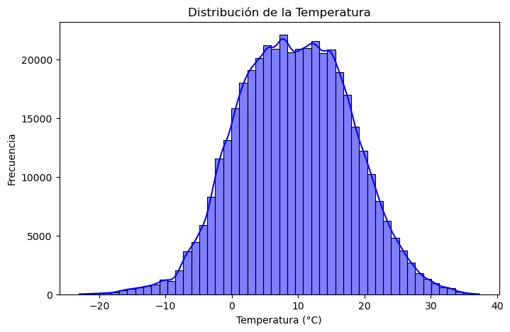

```python
import matplotlib.pyplot as plt

# 📈 Histograma de la temperatura con curva de densidad (KDE)
plt.figure(figsize=(8, 5))
sns.histplot(data["T (degC)"], bins=50, kde=True, color="blue")

# 🏷️ Etiquetas y título
plt.xlabel("Temperatura (°C)")
plt.ylabel("Frecuencia")
plt.title("Distribución de la Temperatura")
plt.show()
```

La forma de la distribución es aproximadamente normal, lo que sugiere que la temperatura varía de manera continua alrededor de un rango típico (5°C a 15°C). Sin embargo, la presencia de valores negativos y extremos indica que hay variaciones estacionales o eventos climáticos que afectan la temperatura a lo largo del tiempo.

Realizaremos una prueba de Shapiro-Wilks para evaluar si la distribución de la temperatura sigue una distribución normal.

# 🔍 Aplicar test de normalidad a la temperatura

```python
from scipy.stats import shapiro

print("Shapiro-Wilk Test:")

stat, p = shapiro(data["T (degC)"])

# 📊 Mostrar estadístico y valor p
print("Statistics = %.6f, p = %e" % (stat, p))

# 🧠 Interpretación
alpha = 0.05
if p > alpha:
    print("✅ La muestra parece normal (no se rechaza H0)")
else:
    print("❌ La muestra no parece normal (se rechaza H0)")
```

```
Shapiro-Wilk Test:
Statistics = 0.998383, p = 3.747271e-42
❌ La muestra no parece normal (se rechaza H0)
```

La hipótesis nula del test establece que los datos siguen una distribución normal. Dado que el p-valor es extremadamente pequeño (< 0.05), rechazamos la hipótesis nula. Esto indica que la distribución de la temperatura no es normal, lo que sugiere que tiene sesgo, colas largas o alguna otra forma de desviación de la normalidad. La distribución sugiere una clara variabilidad de temperatura con una tendencia central entre 5°C y 15°C. El patrón cíclico probablemente indica estacionalidad anual, lo cual debe confirmarse con un análisis más profundo. Los eventos extremos pueden influir en los modelos de predicción, por lo que deben tratarse adecuadamente. Para hacer un análisis más detallado procedemos a aplicar métodos de descomposición y autocorrelación para visualizar la dinámica temporal.

### 🔎 Descomposición de la Serie de tiempo de la Temperatura

📌 Visualización temporal

```python
sns.set_theme(style='whitegrid', palette='muted', context='talk')
```

📊 Gráfica de línea: Tendencia general

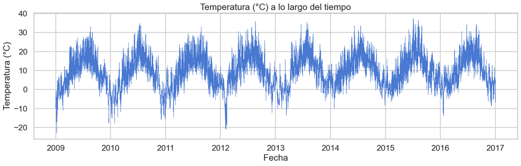

```python
# Convertir columna de fecha a datetime
data["Date Time"] = pd.to_datetime(data["Date Time"], format="%d.%m.%Y %H:%M:%S")


# Definir índice temporal
data.set_index('Date Time', inplace=True)

# Plot general
plt.figure(figsize=(15, 5))
plt.plot(data['T (degC)'], linewidth=0.5)
plt.title('Temperatura (°C) a lo largo del tiempo')
plt.xlabel('Fecha')
plt.ylabel('Temperatura (°C)')
plt.tight_layout()
plt.show()
```

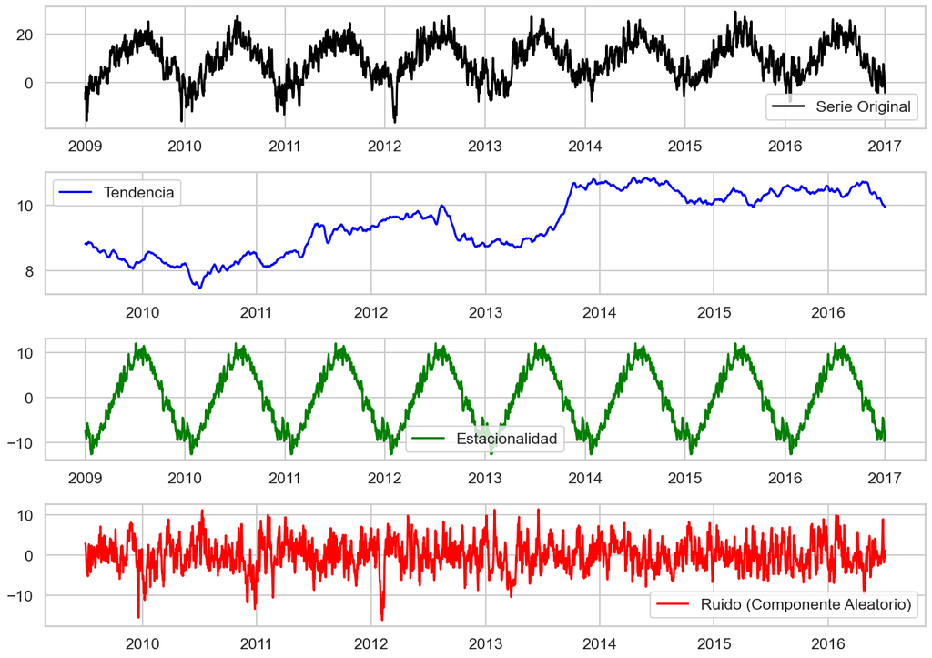

```python
from statsmodels.tsa.seasonal import seasonal_decompose
import matplotlib.pyplot as plt

# Crear la serie diaria promedio
daily_temp = data['T (degC)'].resample('D').mean()
# Descomposición clásica aditiva con periodo anual (365 días)
result = seasonal_decompose(daily_temp.dropna(), model='additive', period=365)

# Gráfica personalizada (similar a tu ejemplo)
plt.figure(figsize=(14, 10))

plt.subplot(411)
plt.plot(result.observed, color='black', label='Serie Original')
plt.legend(loc='best')

plt.subplot(412)
plt.plot(result.trend, color='blue', label='Tendencia')
plt.legend(loc='best')

plt.subplot(413)
plt.plot(result.seasonal, color='green', label='Estacionalidad')
plt.legend(loc='best')

plt.subplot(414)
plt.plot(result.resid, color='red', label='Ruido (Componente Aleatorio)')
plt.legend(loc='best')

plt.tight_layout()
plt.show()
```

**Serie Original (Gráfico 1 - Negro)** Se observa un patrón repetitivo con fluctuaciones estacionales. La temperatura presenta altibajos anuales, lo que sugiere una clara estacionalidad relacionada con las estaciones del año. Hay períodos de temperaturas altas y bajas que parecen mantenerse en ciclos regulares.

**Estacionalidad (Gráfico 3 - Verde)** Se observan ciclos claramente repetitivos cada año, lo que confirma la estacionalidad en la serie. La temperatura sigue un patrón estacional anual, con picos en meses cálidos y valles en meses fríos. Este comportamiento es característico del clima en regiones con estaciones bien definidas.

**Componente Aleatoria (Ruido) (Gráfico 4 - Rojo)** Representa las variaciones no explicadas por la tendencia ni la estacionalidad. Hay fluctuaciones más pronunciadas en ciertos períodos, lo que puede estar relacionado con eventos climáticos extremos, olas de calor o frío. Este ruido puede afectar la precisión de modelos de predicción si no se maneja adecuadamente.

La serie de temperatura presenta un claro comportamiento estacional con ciclos anuales. Existe una tendencia creciente después de 2013, lo que podría sugerir un fenómeno de calentamiento progresivo. El componente aleatorio muestra fluctuaciones, lo que indica que además de la estacionalidad, hay variaciones impredecibles en los datos.

## 📈 Detección visual de Outliers

Usaremos la serie residual (ruido) que obtuvimos de la descomposición, ya que generalmente los outliers destacan más en esta componente.

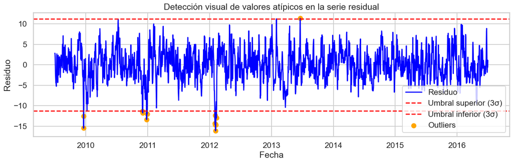

```python
import matplotlib.pyplot as plt
import numpy as np

# Tomamos el residuo de la descomposición previa
residuos = result.resid.dropna()

# Calcular límites para valores atípicos (usando 3 desviaciones estándar)
umbral_superior = residuos.mean() + 3*residuos.std()
umbral_inferior = residuos.mean() - 3*residuos.std()

plt.figure(figsize=(15, 5))
plt.plot(residuos, color='blue', label='Residuo')
plt.axhline(umbral_superior, color='red', linestyle='--', label='Umbral superior (3σ)')
plt.axhline(umbral_inferior, color='red', linestyle='--', label='Umbral inferior (3σ)')

# Resaltar valores atípicos
outliers = residuos[(residuos > umbral_superior) | (residuos < umbral_inferior)]
plt.scatter(outliers.index, outliers, color='orange', label='Outliers')

plt.title('Detección visual de valores atípicos en la serie residual')
plt.xlabel('Fecha')
plt.ylabel('Residuo')
plt.legend()
plt.tight_layout()
plt.show()
```

La mayoría de los residuos se concentran simétricamente alrededor del cero, indicando que la descomposición fue efectiva en captar adecuadamente la tendencia y estacionalidad. Los valores atípicos identificados están principalmente por debajo del umbral inferior, lo que sugiere anomalías significativas en ciertos días específicos con temperaturas notablemente menores a lo esperado. Se observa una concentración más marcada de valores atípicos negativos entre los años 2010 y 2012, lo que podría indicar eventos climáticos excepcionales (por ejemplo, olas de frío inusuales para la temporada) que ameritarían una investigación adicional para comprender su origen

## ⚙️ Detección algorítmica (Z-Score)

```python
from scipy.stats import zscore

# Calcular z-scores
z_scores = zscore(residuos)

# Determinar valores atípicos (umbral estándar de 3 desviaciones)
outliers_z = residuos[np.abs(z_scores) > 3]

print(f"Número total de outliers detectados: {len(outliers_z)}")
print("\nValores atípicos detectados:")
print(outliers_z.head(10))  # mostrar primeros 10 outliers
```

```
Número total de outliers detectados: 15

Valores atípicos detectados:
Date Time
2009-12-19   -15.498
2009-12-20   -12.553
2010-12-01   -11.573
2010-12-02   -11.400
2010-12-03   -11.787
2010-12-26   -13.375
2010-12-29   -12.036
2012-02-02   -14.347
2012-02-03   -14.667
2012-02-04   -12.375
Name: resid, dtype: float64
```

## 📌 1. Análisis visual de estacionalidad anual y mensual

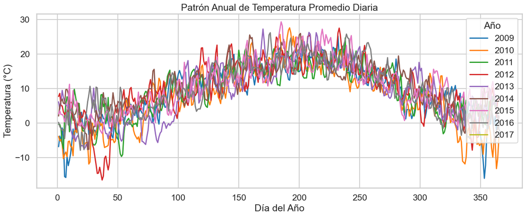

```python
import matplotlib.pyplot as plt
import seaborn as sns

# Preparar datos diarios promedio
daily_temp = data['T (degC)'].resample('D').mean()

# Agregar columnas útiles
temp_df = daily_temp.to_frame(name='Temperatura')
temp_df['Año'] = temp_df.index.year
temp_df['Mes'] = temp_df.index.month
temp_df['Día'] = temp_df.index.dayofyear

# Visualización del patrón anual por año
plt.figure(figsize=(14, 6))
sns.lineplot(data=temp_df, x='Día', y='Temperatura', hue='Año', palette='tab10', legend='full')
plt.title('Patrón Anual de Temperatura Promedio Diaria')
plt.xlabel('Día del Año')
plt.ylabel('Temperatura (°C)')
plt.legend(title='Año', loc='upper right')
plt.tight_layout()
plt.show()
```

## 📌 2. Boxplot mensual para observar ciclos recurrentes mes a mes

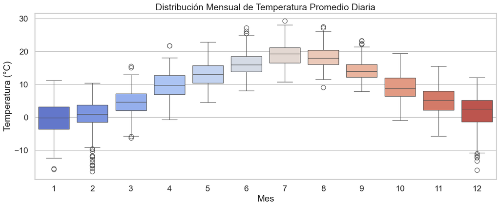

```python
plt.figure(figsize=(14, 6))
sns.boxplot(data=temp_df, x='Mes', y='Temperatura', palette='coolwarm')
plt.title('Distribución Mensual de Temperatura Promedio Diaria')
plt.xlabel('Mes')
plt.ylabel('Temperatura (°C)')
plt.tight_layout()
plt.show()
```

Se observa una clara estacionalidad anual en la temperatura. Las temperaturas más bajas se concentran en invierno (meses 1, 2, 12), mientras que los meses más cálidos ocurren en verano (6, 7, 8).

El mes más frío es enero (1), seguido de febrero (2) y diciembre (12). Estos meses presentan también la mayor cantidad de valores atípicos negativos (temperaturas extremadamente bajas), particularmente febrero.

## 📊 Gráfica de Autocorrelación (ACF)

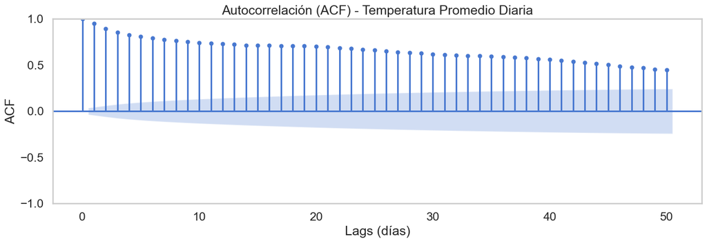

```python
import matplotlib.pyplot as plt
from statsmodels.graphics.tsaplots import plot_acf, plot_pacf

# Utilizar temperatura diaria promedio
daily_temp = data['T (degC)'].resample('D').mean().dropna()

# Graficar ACF
plt.figure(figsize=(14,5))
plot_acf(daily_temp, lags=50, ax=plt.gca())
plt.title('Autocorrelación (ACF) - Temperatura Promedio Diaria')
plt.xlabel('Lags (días)')
plt.ylabel('ACF')
plt.grid()
plt.tight_layout()
plt.show()
```

La autocorrelación presenta valores muy altos en los primeros rezagos, decreciendo lentamente de forma gradual. Esto sugiere claramente una fuerte dependencia temporal en la serie, típica en series climáticas debido a la naturaleza lenta de los cambios diarios en la temperatura.

La disminución lenta sugiere que la serie no es estacionaria en su forma original, indicando necesidad de aplicar diferenciación o técnicas similares para modelarla.

## 📊 Gráfica de Autocorrelación Parcial (PACF)

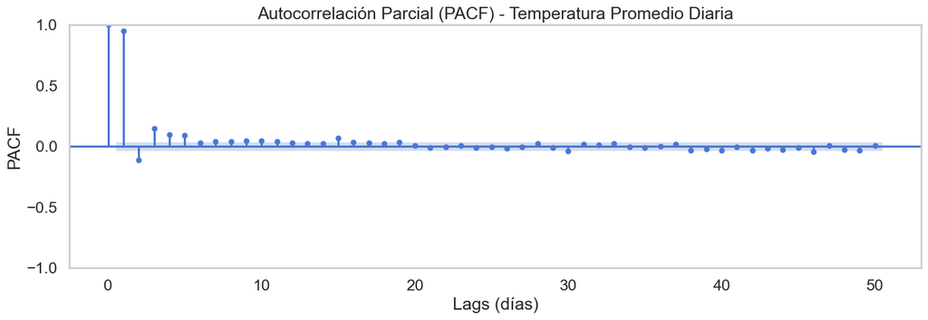

```python
# Graficar PACF
plt.figure(figsize=(14,5))
plot_pacf(daily_temp, lags=50, ax=plt.gca(), method='ywm')
plt.title('Autocorrelación Parcial (PACF) - Temperatura Promedio Diaria')
plt.xlabel('Lags (días)')
plt.ylabel('PACF')
plt.grid()
plt.tight_layout()
plt.show()
```

La PACF muestra un pico muy fuerte en el primer rezago, indicando que existe una fuerte dependencia directa con el día inmediatamente anterior. Este es un comportamiento típico en variables climáticas como la temperatura. Después del primer rezago, la PACF decae abruptamente hacia valores cercanos a cero, aunque aún se observan algunos rezagos menores que superan ligeramente la banda de significancia estadística.

Este patrón indica claramente que un modelo autoregresivo (AR) con un orden relativamente bajo (probablemente AR(1) o AR(2)) podría ser suficiente inicialmente para explicar la dependencia directa diaria.

Para avanzar en modelado predictivo, es posible considerar primero una diferenciación para eliminar la no estacionariedad y después seleccionar términos AR y MA en base a estos resultados.

## 📌 Agrupación por períodos relevantes

# Promedio mensual

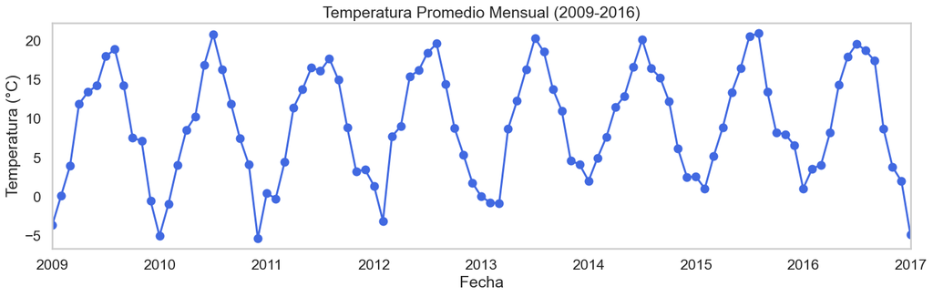

```python
import matplotlib.pyplot as plt

# Promedio mensual
monthly_temp = data['T (degC)'].resample('M').mean()

# Gráfica del promedio mensual
plt.figure(figsize=(15,5))
monthly_temp.plot(marker='o', color='royalblue')
plt.title('Temperatura Promedio Mensual (2009-2016)')
plt.xlabel('Fecha')
plt.ylabel('Temperatura (°C)')
plt.grid()
plt.tight_layout()
plt.show()
```

# Promedio semanal

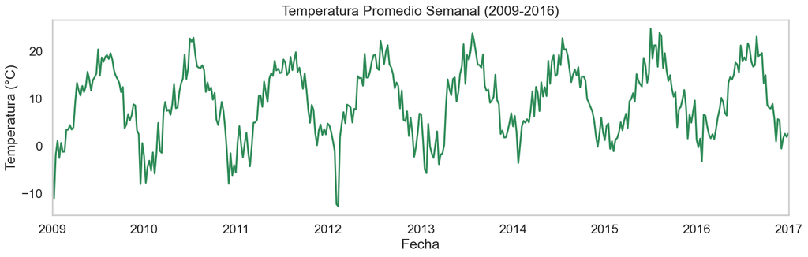

```python
# Promedio semanal
weekly_temp = data['T (degC)'].resample('W').mean()

# Gráfica del promedio semanal
plt.figure(figsize=(15,5))
weekly_temp.plot(color='seagreen')
plt.title('Temperatura Promedio Semanal (2009-2016)')
plt.xlabel('Fecha')
plt.ylabel('Temperatura (°C)')
plt.grid()
plt.tight_layout()
plt.show()
```

## 📌 Análisis de patrones diarios, semanales y anuales

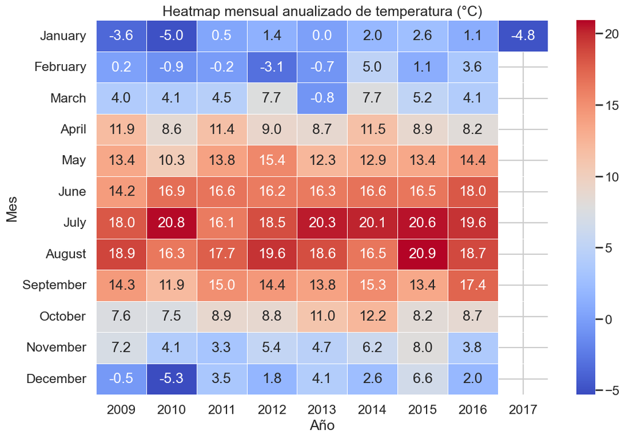

```python
# Matriz de temperatura mensual por año
pivot_temp = data['T (degC)'].resample('M').mean().to_frame()
pivot_temp['Año'] = pivot_temp.index.year
pivot_temp['Mes'] = pivot_temp.index.month_name()

temp_pivot = pivot_temp.pivot(index='Mes', columns='Año', values='T (degC)')

# Orden cronológico correcto de meses
months_order = ['January', 'February', 'March', 'April', 'May', 'June', 'July', 'August',
                'September', 'October', 'November', 'December']
temp_pivot = temp_pivot.reindex(months_order)

# Heatmap
plt.figure(figsize=(12,8))
sns.heatmap(temp_pivot, cmap='coolwarm', annot=True, fmt=".1f", linewidths=0.5)
plt.title('Heatmap mensual anualizado de temperatura (°C)')
plt.xlabel('Año')
plt.ylabel('Mes')
plt.tight_layout()
plt.show()
```

Se observa claramente una fuerte estacionalidad anual recurrente, con meses fríos (tonos azules) durante el invierno (Diciembre, Enero, Febrero) y meses cálidos (tonos rojos) en verano (Junio, Julio, Agosto). La gráfica confirma claramente una fuerte y estable estacionalidad anual en la temperatura del dataset.

## 📌Análisis de tendencias: Suavizamiento mediante medias móviles

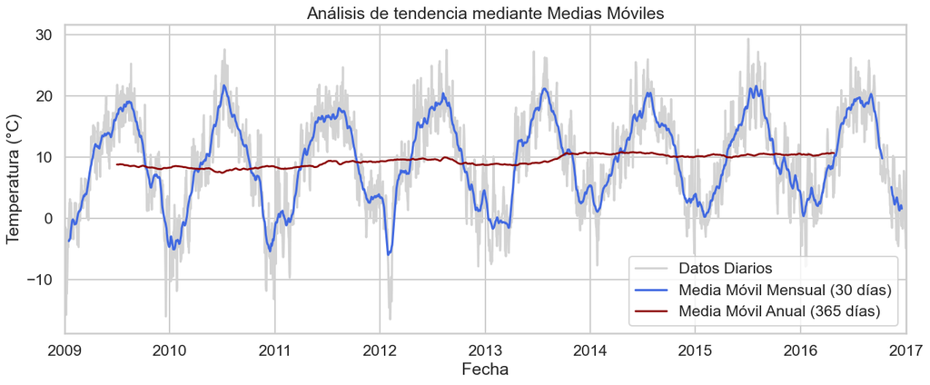

```python
import matplotlib.pyplot as plt

# Temperatura diaria promedio
daily_temp = data['T (degC)'].resample('D').mean()

# Media móvil mensual (~30 días) y anual (~365 días)
rolling_monthly = daily_temp.rolling(window=30, center=True).mean()
rolling_annual = daily_temp.rolling(window=365, center=True).mean()

# Gráfica
plt.figure(figsize=(14,6))
daily_temp.plot(color='lightgray', label='Datos Diarios')
rolling_monthly.plot(color='royalblue', label='Media Móvil Mensual (30 días)')
rolling_annual.plot(color='darkred', linewidth=2, label='Media Móvil Anual (365 días)')
plt.title('Análisis de tendencia mediante Medias Móviles')
plt.xlabel('Fecha')
plt.ylabel('Temperatura (°C)')
plt.legend()
plt.tight_layout()
plt.show()
```

## 📌 Visualización de tendencias mediante regresión lineal

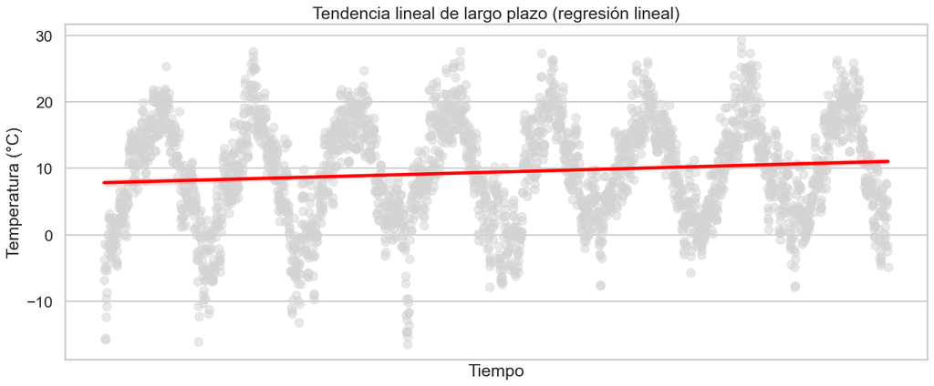

```python
import numpy as np
import seaborn as sns

# Preparar datos para regresión
daily_temp_df = daily_temp.reset_index()
daily_temp_df['Fecha_Num'] = np.arange(len(daily_temp_df))

# Gráfica con regresión lineal
plt.figure(figsize=(14,6))
sns.regplot(x='Fecha_Num', y='T (degC)', data=daily_temp_df,
            scatter_kws={'color':'lightgray', 'alpha':0.5},
            line_kws={'color':'red'})
plt.title('Tendencia lineal de largo plazo (regresión lineal)')
plt.xlabel('Tiempo')
plt.ylabel('Temperatura (°C)')
plt.xticks([])  # Para simplificar visualización del tiempo
plt.tight_layout()
plt.show()
```

La línea roja de regresión muestra una leve pendiente ascendente, indicando una muy ligera tendencia de incremento de la temperatura promedio diaria a lo largo de los años 2009-2016.

Aunque la pendiente es pequeña, su orientación ascendente sugiere que, en promedio, las temperaturas han tenido un leve aumento a largo plazo durante el período analizado.

Esta tendencia, aunque ligera, podría ser significativa desde un punto de vista climático, indicando un potencial calentamiento suave durante el período analizado, que podría ser relevante en estudios de cambios climáticos a largo plazo.

## 🧪 Análisis estacionariedad

# 📋 Test Dickey Fuller Aumentada

```python
from statsmodels.tsa.stattools import adfuller

# Crear serie diaria (promedio de temperatura por día)
serie = data['T (degC)'].resample('D').mean()
# Eliminar nulos (muy importante para evitar errores)
serie = serie.dropna()

# Aplicar ADF
resultado_adf = adfuller(serie)

# Mostrar resultados
print("Estadístico ADF:", resultado_adf[0])
print("Valor p:", resultado_adf[1])
print("Valores críticos:")
for clave, valor in resultado_adf[4].items():
    print(f"   {clave}: {valor:.4f}")
```

```
Estadístico ADF: -3.5840984085553247
Valor p: 0.0060724110111168485
Valores críticos:
   1%: -3.4326
   5%: -2.8625
   10%: -2.5673
```

La serie parece ser estacionaria a nivel global, pero para estar seguro realizaremos un submuestreo, para poder ver el comportamiento de la media y varianza en submuestras.

## 📊 Visualización de Media y Varianza en submuestras

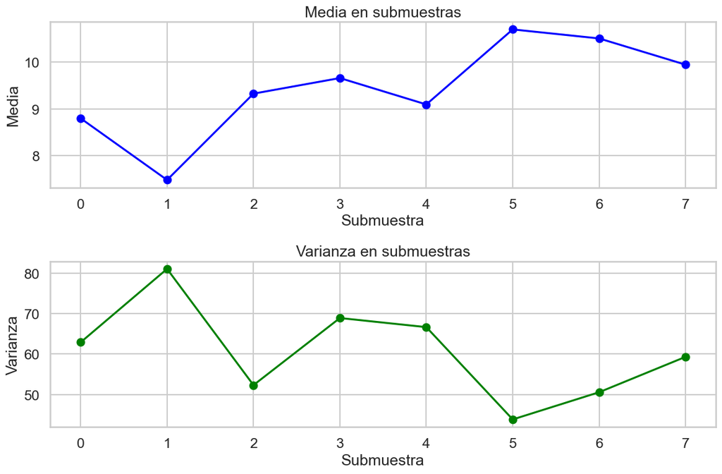

```python
import numpy as np
import matplotlib.pyplot as plt

# Dividir datos en 8 segmentos iguales para evaluar media y varianza
split = np.array_split(daily_temp, 8)

means = [s.mean() for s in split]
variances = [s.var() for s in split]

# Graficar media y varianza
fig, ax = plt.subplots(2, 1, figsize=(12,8))

# Media
ax[0].plot(means, marker='o', color='blue')
ax[0].set_title('Media en submuestras')
ax[0].set_xlabel('Submuestra')
ax[0].set_ylabel('Media')

# Varianza
ax[1].plot(variances, marker='o', color='green')
ax[1].set_title('Varianza en submuestras')
ax[1].set_xlabel('Submuestra')
ax[1].set_ylabel('Varianza')

plt.tight_layout()
plt.show()
```

## 🔍 Test Dickey Fuller en ventanas móviles

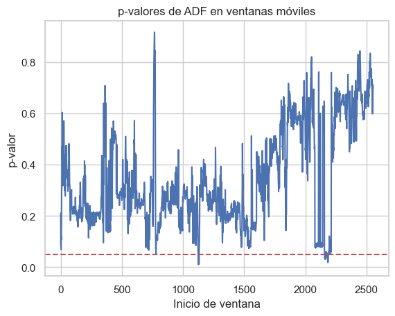

```python
from statsmodels.tsa.stattools import adfuller

ventana = 365  # un año
adf_resultados = []

for i in range(0, len(serie) - ventana):
    ventana_movil = serie[i:i+ventana]
    resultado = adfuller(ventana_movil.dropna())
    adf_resultados.append(resultado[1])  # solo guardo el valor p

# Visualizar cómo cambia el p-valor en el tiempo
import matplotlib.pyplot as plt

plt.plot(adf_resultados)
plt.axhline(y=0.05, color='r', linestyle='--')
plt.title("p-valores de ADF en ventanas móviles")
plt.xlabel("Inicio de ventana")
plt.ylabel("p-valor")
plt.show()
```

La línea roja punteada marca el umbral de significancia típico (0.05). Por debajo de ella, rechazamos la hipótesis nula de no estacionariedad. Hay varios periodos donde el valor p < 0.05, lo que indica estacionariedad local en esos tramos. Sin embargo, hay muchos tramos donde el valor p > 0.05, incluso llegando a 0.8 o más, lo que implica que en esas ventanas la serie no es estacionaria. La serie es globalmente estacionaria (como mostró ADF inicial), pero no lo es de forma consistente a lo largo del tiempo.

## 🔁 Transformación de Datos

Vamos aplicar transformaciones y descomposición para mejorar la estacionariedad y aislar la estacionalidad

| Acción | Objetivo principal | Afecta a | Uso típico |
| --- | --- | --- | --- |
| Transformar | Estabilizar la varianza y eliminar tendencia | Toda la serie | Para lograr estacionariedad global y aplicar modelos como ARIMA |
| Descomponer | Separar tendencia, estacionalidad y residuales | Componentes | Para analizar o modelar por partes (e.g., modelar solo los residuales) |

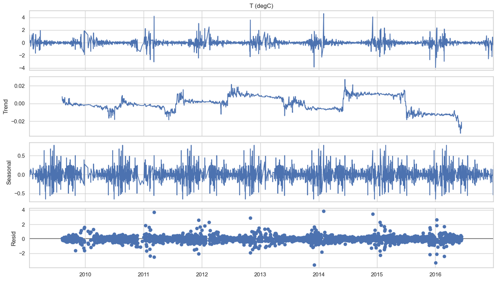

```
(np.float64(-10.562978424989197),
 np.float64(7.643324191699709e-19),
 {'1%': np.float64(-3.4328910824047996),
  '5%': np.float64(-2.8626626512684394),
  '10%': np.float64(-2.5673676282804)})
```

```python
# Reejecutar todo porque el entorno fue reiniciado
import pandas as pd
import numpy as np
import matplotlib.pyplot as plt
from statsmodels.tsa.stattools import adfuller
from statsmodels.tsa.seasonal import seasonal_decompose

# Resampleo diario de la temperatura promedio
serie = data['T (degC)'].resample('D').mean().dropna()

# Transformación logarítmica
serie_log = np.log1p(serie)

# Diferenciación
serie_log_diff = serie_log.diff().dropna()

# Prueba ADF
adf_resultado = adfuller(serie_log_diff)

# Descomposición
descomposicion_log_diff = seasonal_decompose(serie_log_diff, model='additive', period=365)

# Graficar
fig = descomposicion_log_diff.plot()
fig.set_size_inches(14, 8)
plt.tight_layout()
plt.show()

# Resultados de la prueba ADF
adf_estadistico = adf_resultado[0]
adf_pvalor = adf_resultado[1]
adf_criticos = adf_resultado[4]

(adf_estadistico, adf_pvalor, adf_criticos)
```

## 📋 Test Dickey Fuller Aumentado

```python
from statsmodels.tsa.stattools import adfuller

# ADF sobre serie diferenciada
adf_result = adfuller(serie_log_diff.dropna())
print(f"ADF Statistic: {adf_result[0]:.4f}")
print(f"p-value: {adf_result[1]:.4f}")
```

```
ADF Statistic: -16.9610
p-value: 0.0000
```

📊 3. Descomposición estacional Se observan componentes estacionales consistentes, aunque más sutiles tras la diferenciación. La tendencia fue eliminada casi por completo. Los residuales no muestran patrones estructurados, lo cual es ideal para modelado.

## 📊 Matriz de correlación

```python
datos = pd.read_csv("C:/Users/10Pearls/Documents/Proyecto final/datos/jena_climate_2009_2016.csv")
datos["Date Time"] = pd.to_datetime(datos["Date Time"], format="%d.%m.%Y %H:%M:%S")
datos.set_index('Date Time', inplace=True)
```

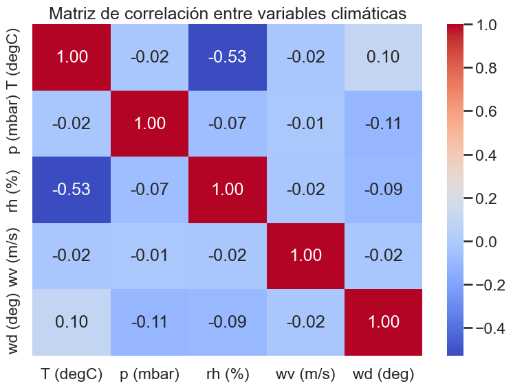

```python
# Resample diario
daily_df = datos.resample('D').mean()

# Seleccionar variables climáticas
variables = ['T (degC)', 'p (mbar)', 'rh (%)', 'wv (m/s)', 'wd (deg)']
correlacion = daily_df[variables].corr()

# Visualización con heatmap
import seaborn as sns
import matplotlib.pyplot as plt

plt.figure(figsize=(8,6))
sns.heatmap(correlacion, annot=True, cmap='coolwarm', fmt=".2f")
plt.title('Matriz de correlación entre variables climáticas')
plt.tight_layout()
plt.show()
```

## 📈 Gráficos de dispersión (relaciones no lineales)

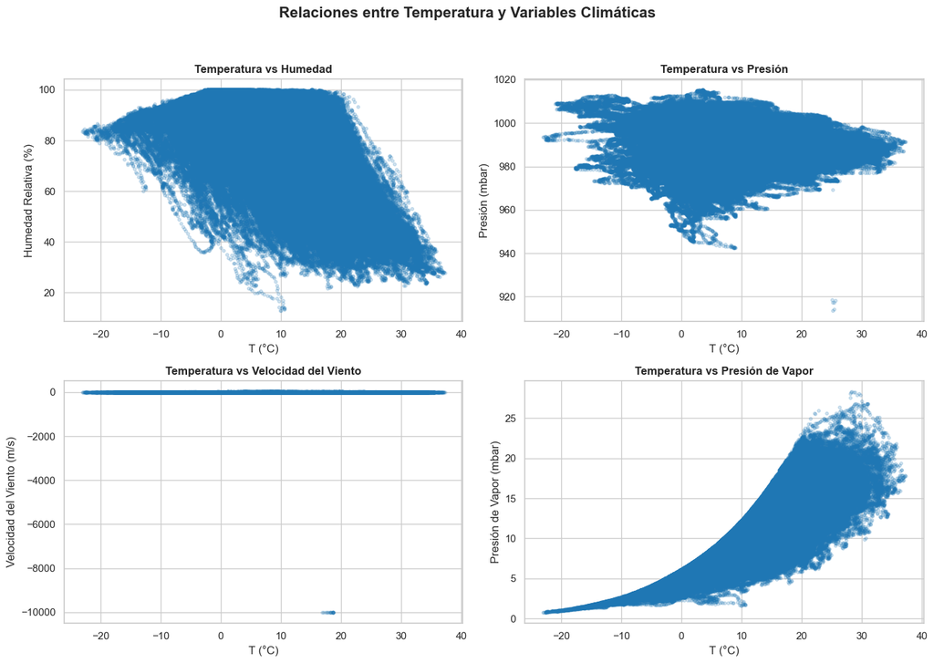

```python
import matplotlib.pyplot as plt
# Volver a cargar el CSV desde cero
datos = pd.read_csv("C:/Users/10Pearls/Documents/Proyecto final/datos/jena_climate_2009_2016.csv")
# Asegúrate de tener la columna 'Date Time' como índice datetime
datos["Date Time"] = pd.to_datetime(datos["Date Time"], format="%d.%m.%Y %H:%M:%S")
datos.set_index('Date Time', inplace=True)

# Selección de variables
x = datos['T (degC)']
y1 = datos['rh (%)']          # Humedad relativa
y2 = datos['p (mbar)']        # Presión
y3 = datos['wv (m/s)']        # Velocidad del viento
y4 = datos['VPact (mbar)']    # Presión de vapor (puede variar el nombre exacto)

import matplotlib.pyplot as plt
import seaborn as sns

# Estilo general
sns.set_theme(style="whitegrid")

# Crear figura
fig, axs = plt.subplots(2, 2, figsize=(14, 10))
fig.suptitle('Relaciones entre Temperatura y Variables Climáticas', fontsize=16, fontweight='bold')

# Personalizar puntos
scatter_kws = {'alpha': 0.2, 's': 10, 'color': '#1f77b4'}

# Gráfico 1: Temperatura vs Humedad
axs[0, 0].scatter(datos['T (degC)'], datos['rh (%)'], **scatter_kws)
axs[0, 0].set_title('Temperatura vs Humedad', fontsize=12, fontweight='bold')
axs[0, 0].set_xlabel('T (°C)')
axs[0, 0].set_ylabel('Humedad Relativa (%)')

# Gráfico 2: Temperatura vs Presión
axs[0, 1].scatter(datos['T (degC)'], datos['p (mbar)'], **scatter_kws)
axs[0, 1].set_title('Temperatura vs Presión', fontsize=12, fontweight='bold')
axs[0, 1].set_xlabel('T (°C)')
axs[0, 1].set_ylabel('Presión (mbar)')

# Gráfico 3: Temperatura vs Velocidad del Viento
axs[1, 0].scatter(datos['T (degC)'], datos['wv (m/s)'], **scatter_kws)
axs[1, 0].set_title('Temperatura vs Velocidad del Viento', fontsize=12, fontweight='bold')
axs[1, 0].set_xlabel('T (°C)')
axs[1, 0].set_ylabel('Velocidad del Viento (m/s)')

# Gráfico 4: Temperatura vs Presión de Vapor
axs[1, 1].scatter(datos['T (degC)'], datos['VPact (mbar)'], **scatter_kws)
axs[1, 1].set_title('Temperatura vs Presión de Vapor', fontsize=12, fontweight='bold')
axs[1, 1].set_xlabel('T (°C)')
axs[1, 1].set_ylabel('Presión de Vapor (mbar)')

# Ajuste de espaciado
plt.tight_layout(rect=[0, 0, 1, 0.95])
plt.show()
```

En los gráficos se puede observar que la variable T (degC) (Temperatura) tiene varias relaciones no lineales con otras variables meteorológicas. A continuación, se analizan algunas de estas relaciones:

Temperatura vs Presión (mbar): La relación entre temperatura y presión también parece ser no lineal, con una ligera disminución de la presión conforme la temperatura aumenta, pero la pendiente de la curva varía a lo largo de los valores de temperatura. Esta relación refleja cómo la temperatura afecta a la densidad del aire y, por ende, a la presión atmosférica, aunque la tendencia no es tan estrictamente lineal.

Temperatura vs Presión de Vapor (Vpact, mbar): La relación entre la temperatura y la presión de vapor parece seguir una curva exponencial. A medida que la temperatura aumenta, la presión de vapor aumenta de manera más pronunciada, lo que refleja la mayor capacidad del aire para retener vapor de agua a temperaturas más altas. Esta relación es un ejemplo típico de un comportamiento no lineal, ya que la presión de vapor aumenta de forma acelerada con la temperatura.

En resumen, varias de las relaciones entre la temperatura y otras variables son no lineales, lo que sugiere que los cambios en las variables meteorológicas no siguen una simple regla lineal, sino que presentan un comportamiento más complejo y en algunos casos exponencial, especialmente en lo que respecta a la presión de vapor.

## 📊 Análisis de la Transformada de Fourier

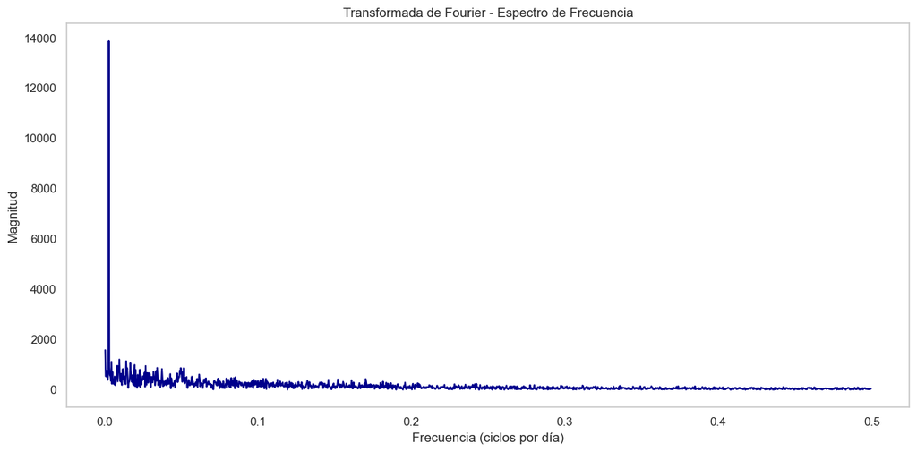

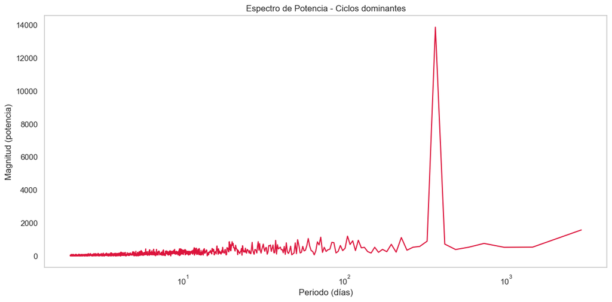

```python
import numpy as np
import pandas as pd
import matplotlib.pyplot as plt
# Usamos la temperatura diaria promedio
temp_diaria = datos['T (degC)'].resample('D').mean().dropna()

# Convertir la serie a array NumPy
serie = temp_diaria.values
n = len(serie)
from scipy.fft import fft, fftfreq

# FFT y frecuencia asociada
fft_vals = fft(serie)
fft_magnitudes = np.abs(fft_vals)[:n//2]  # Solo mitad positiva
frecuencias = fftfreq(n, d=1)[:n//2]


plt.figure(figsize=(12,6))
plt.plot(frecuencias[1:], fft_magnitudes[1:], color='darkblue')  # quitamos frecuencia 0
plt.title('Transformada de Fourier - Espectro de Frecuencia')
plt.xlabel('Frecuencia (ciclos por día)')
plt.ylabel('Magnitud')
plt.grid()
plt.tight_layout()
plt.show()

periodos = 1 / frecuencias[1:]  # saltamos el valor 0 para evitar división por cero

plt.figure(figsize=(12,6))
plt.plot(periodos, fft_magnitudes[1:], color='crimson')
plt.xscale('log')  # Escala logarítmica para mejor visibilidad
plt.title('Espectro de Potencia - Ciclos dominantes')
plt.xlabel('Periodo (días)')
plt.ylabel('Magnitud (potencia)')
plt.grid()
plt.tight_layout()
plt.show()
```

Gráfica Transformada de Fourier Después del pico inicial, la magnitud disminuye rápidamente a medida que aumenta la frecuencia. Esto indica que las componentes de alta frecuencia de la señal tienen una magnitud mucho menor, lo que puede sugerir que la señal es relativamente suave y no presenta fluctuaciones rápidas.

Este espectro de frecuencia muestra que la señal tiene una fuerte componente de baja frecuencia, lo que implica que las fluctuaciones importantes de la señal ocurren a una escala temporal más larga (posiblemente ciclos estacionales o de largo plazo). Las componentes de alta frecuencia tienen poca magnitud, lo que indica que las fluctuaciones rápidas son menos significativas.

Espectro de potencia de la temperatura

## 🔎Detección de picos inusuales en la temperatura

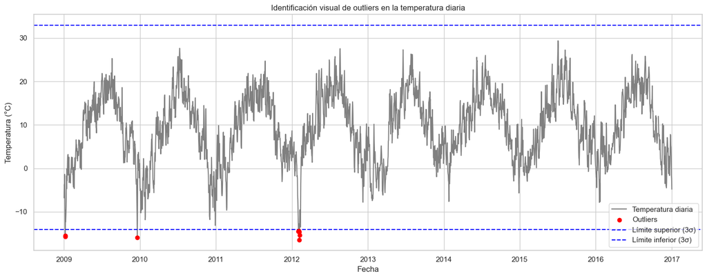

```python
import matplotlib.pyplot as plt

# Serie de temperatura diaria
temp_diaria = datos['T (degC)'].resample('D').mean()

# Umbrales: media ± 3 desviaciones estándar
media = temp_diaria.mean()
std = temp_diaria.std()
limite_sup = media + 3 * std
limite_inf = media - 3 * std

# Detectar outliers
outliers = temp_diaria[(temp_diaria > limite_sup) | (temp_diaria < limite_inf)]

# Graficar
plt.figure(figsize=(15,6))
plt.plot(temp_diaria, label='Temperatura diaria', color='gray')
plt.scatter(outliers.index, outliers, color='red', label='Outliers', zorder=5)
plt.axhline(limite_sup, color='blue', linestyle='--', label='Límite superior (3σ)')
plt.axhline(limite_inf, color='blue', linestyle='--', label='Límite inferior (3σ)')
plt.title('Identificación visual de outliers en la temperatura diaria')
plt.xlabel('Fecha')
plt.ylabel('Temperatura (°C)')
plt.legend()
plt.tight_layout()
plt.show()
```

## 📊 Detección estadística con modelos

▶️ a) Método de rango intercuartílico (IQR)

```python
Q1 = temp_diaria.quantile(0.25)
Q3 = temp_diaria.quantile(0.75)
IQR = Q3 - Q1

iqr_outliers = temp_diaria[(temp_diaria < Q1 - 1.5 * IQR) | (temp_diaria > Q3 + 1.5 * IQR)]
print(f"Outliers (IQR): {len(iqr_outliers)}")
```

```
Outliers (IQR): 8
```

## 🔎 Resumen de Hallazgos Claves

Patrones Generales

Tendencia Ascendente: La temperatura media diaria muestra un aumento a lo largo de los años, lo que sugiere un posible cambio climático o variabilidad climática de largo plazo. Estacionalidad Anual Fuerte: Se observan ciclos recurrentes con picos en verano y bajas temperaturas en invierno, confirmados por la descomposición de la serie y el análisis de autocorrelación (ACF y PACF). Dependencia Temporal: La temperatura de un día está altamente correlacionada con los días anteriores, lo que justifica el uso de modelos como SARIMA o modelos autoregresivos.

Anomalías y Eventos Extremos

Análisis de Estacionariedad

La diferenciación (d=1) permitió hacerla estacionaria, confirmada por la prueba Dickey-Fuller (ADF). Los ciclos estacionales sugieren que un modelo SARIMA es más adecuado que un ARIMA simple.

## 🧾 Pasos a seguir:

## Ajustes para la Modelización

**Manejo de Problemas Detectados**

No Estacionariedad Aplicar diferenciación. Transformación logaritmica (Conversar con el profesor) Usar modelos con términos estacionales (SARIMA, Prophet, LSTM con ventanas de tiempo).

**Valores Atípicos**

-Eliminar outliers si son errores de medición. -Mantener outliers si representan eventos climáticos reales y usarlos para entrenar modelos de predicción de eventos extremos.

**Mejorar la Calidad de Datos** Evaluar otras variables climáticas (humedad, presión, viento) para mejorar la predicción con un enfoque multivariado.

### 🔮 Conclusión Final

La serie de temperatura es predecible con modelos estacionales debido a su fuerte periodicidad. La eliminación de outliers y la diferenciación mejoran la precisión de los modelos. Probar con modelos SARIMA, LSTM, o Modelos Transformers para optimizar las predicciones.

## ✅ Confirmar que log_diff_temp está lista

```python
# Verifica índice y nulos
print(serie_log_diff.index)  # Debe ser DateTimeIndex
print(serie_log_diff.isna().sum())  # Debe ser 0
```

```
DatetimeIndex(['2009-01-18', '2009-01-19', '2009-01-20', '2009-01-24',
               '2009-01-25', '2009-02-03', '2009-02-06', '2009-02-07',
               '2009-02-08', '2009-02-09',
               ...
               '2016-12-16', '2016-12-19', '2016-12-20', '2016-12-23',
               '2016-12-24', '2016-12-25', '2016-12-26', '2016-12-27',
               '2016-12-28', '2016-12-29'],
              dtype='datetime64[ns]', name='Date Time', length=2599, freq=None)
0
```

## 📦 Importar librerías y definir modelo SARIMA

Modelo inicial #no corrió

```python
#from statsmodels.tsa.statespace.sarimax import SARIMAX
import matplotlib.pyplot as plt

# Parámetros iniciales: (p,d,q)(P,D,Q,s)
# Tú ya hiciste 1 diferenciación => d = 0 aquí porque ya está diferenciada
# Estacionalidad anual (s=365 para datos diarios)
#modelo_estacional = SARIMAX(log_diff_temp,
                            #order=(1, 0, 1),             # parte no estacional
                            #seasonal_order=(1, 0, 1, 365), # parte estacional
                            #enforce_stationarity=False,
                            #enforce_invertibility=False)

#resultado_estacional = modelo_estacional.fit(disp=False)
#print(resultado_estacional.summary()
```

## ✅ Modelo SARIMA Frecuencia Semanal para reducir complejidad

```python
# Resampleo diario y cálculo del promedio
serie = data['T (degC)'].resample('D').mean().dropna()

# Transformación logarítmica
serie_log = np.log1p(serie)

# Diferenciación para eliminar tendencia
serie_log_diff = serie_log.diff().dropna()

# Cambiar frecuencia a semanal para reducir complejidad
serie_semanal_diff = serie_log_diff.resample('W').mean().dropna()

# Ajustar modelo SARIMA con estacionalidad 52 (semanal) y orden (1,0,1)
from statsmodels.tsa.statespace.sarimax import SARIMAX

modelo_sarima = SARIMAX(
    serie_semanal_diff,
    order=(1, 0, 1),
    seasonal_order=(1, 0, 1, 52),
    enforce_stationarity=False,
    enforce_invertibility=False
).fit()

modelo_sarima.summary()
```

SARIMAX Results

| Dep. Variable: | T (degC) | No. Observations: | 404 |
| --- | --- | --- | --- |
| Model: | SARIMAX(1, 0, 1)x(1, 0, 1, 52) | Log Likelihood | -2.981 |
| Date: | Wed, 09 Apr 2025 | AIC | 15.962 |
| Time: | 14:22:35 | BIC | 35.252 |
| Sample: | 0 | HQIC | 23.640 |
|  | - 404 |  |  |
| Covariance Type: | opg |  |  |

|  | coef | std err | z | P>\|z\| | [0.025 | 0.975] |
| --- | --- | --- | --- | --- | --- | --- |
| ar.L1 | -0.3756 | 0.146 | -2.576 | 0.010 | -0.661 | -0.090 |
| ma.L1 | 0.1268 | 0.154 | 0.823 | 0.411 | -0.175 | 0.429 |
| ar.S.L52 | 0.4132 | 0.074 | 5.569 | 0.000 | 0.268 | 0.559 |
| ma.S.L52 | -0.5849 | 0.073 | -7.983 | 0.000 | -0.728 | -0.441 |
| sigma2 | 0.0560 | 0.001 | 40.207 | 0.000 | 0.053 | 0.059 |

| Ljung-Box (L1) (Q): | 0.05 | Jarque-Bera (JB): | 15675.84 |
| --- | --- | --- | --- |
| Prob(Q): | 0.82 | Prob(JB): | 0.00 |
| Heteroskedasticity (H): | 1.52 | Skew: | -2.78 |
| Prob(H) (two-sided): | 0.02 | Kurtosis: | 35.31 |

Warnings:  
[1] Covariance matrix calculated using the outer product of gradients (complex-step).

### 🔢 **Parámetros estimados**

| Parámetro | Coef. | P-valor | Significativo |
| --- | --- | --- | --- |
| AR(1) | -0.3756 | 0.010 | ✅ Sí |
| MA(1) | 0.1268 | 0.411 | ❌ No |
| SAR(52) | 0.4132 | 0.000 | ✅ Sí |
| SMA(52) | -0.5849 | 0.000 | ✅ Sí |
| Varianza | 0.0560 | 0.000 | — |

### 📊 **Estadísticos del modelo**

- **AIC**: 15.96 → muy bajo (excelente)
- **BIC**: 35.25
- **Log-Likelihood**: -2.98

### 📉 **Diagnóstico de residuos**

- **Ljung-Box p-valor**: 0.82 → no hay autocorrelación en los residuos (✅)
- **Jarque-Bera p-valor**: 0.00 → residuos no normales (⚠️)
- **Skew**: -2.78 → asimetría negativa fuerte
- **Kurtosis**: 35.31 → leptocúrtico (picos y colas extremas)

## 📊 Pronóstico

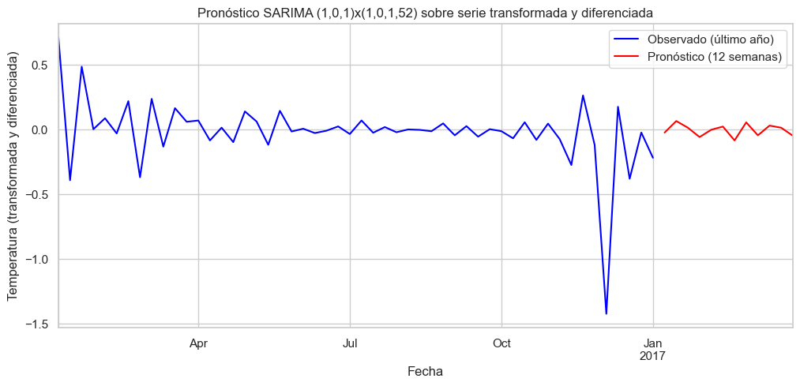

```python
import pandas as pd
import matplotlib.pyplot as plt
from datetime import timedelta

# 1. Crear un índice de fechas válido
start_date = serie_semanal_diff.index[-1] + timedelta(weeks=1)
forecast_index = pd.date_range(start=start_date, periods=12, freq='W')

# 2. Asegurar que forecast_diff sea un Series con nombre e índice de fechas
forecast_series = pd.Series(forecast_diff.values, index=forecast_index, name='Pronóstico')

# 3. Graficar pronóstico
plt.figure(figsize=(12, 5))
serie_semanal_diff[-52:].plot(label="Observado (último año)", color='blue')
forecast_series.plot(label="Pronóstico (12 semanas)", color='red')
plt.title("Pronóstico SARIMA (1,0,1)x(1,0,1,52) sobre serie transformada y diferenciada")
plt.xlabel("Fecha")
plt.ylabel("Temperatura (transformada y diferenciada)")
plt.legend()
plt.grid(True)
plt.show()
```

## 📊 Métricas de Desempeño del Modelo

```python
from sklearn.metrics import mean_absolute_error, mean_squared_error
from statsmodels.stats.diagnostic import acorr_ljungbox
import numpy as np
from datetime import timedelta

# Índice correcto para forecast
start_date = serie_semanal_diff.index[-1] + timedelta(weeks=1)
forecast_index = pd.date_range(start=start_date, periods=12, freq='W')

# Crear serie pronosticada con índice de fechas
forecast_series = pd.Series(forecast_diff.values, index=forecast_index, name='Pronóstico')

# Paso 1: reconstruir valores en escala original
ultimo_valor_real = serie_log.resample('W').mean().dropna().iloc[-1]
forecast_acumulado = forecast_series.cumsum() + ultimo_valor_real
forecast_final = np.expm1(forecast_acumulado)

# Paso 2: valores reales para comparación
real = serie['2016-10-16':].resample('W').mean().iloc[:12]

# Paso 3: métricas
mape = np.mean(np.abs((real.values - forecast_final.values) / real.values)) * 100
mae = mean_absolute_error(real.values, forecast_final.values)
mse = mean_squared_error(real.values, forecast_final.values)
rmse = np.sqrt(mse)

# Paso 4: prueba de Ljung-Box
residuos = modelo_sarima.resid
lb_test = acorr_ljungbox(residuos, lags=[1], return_df=True)
lb_pvalor = lb_test["lb_pvalue"].values[0]

# Resultados
{
    "MAPE (%)": mape,
    "MAE": mae,
    "MSE": mse,
    "RMSE": rmse,
    "Ljung-Box p-valor (lag=1)": lb_pvalor
}
```

```
{'MAPE (%)': np.float64(187.76429777491126),
 'MAE': 3.0742452872417,
 'MSE': 12.744739521766812,
 'RMSE': np.float64(3.5699775239862244),
 'Ljung-Box p-valor (lag=1)': np.float64(0.23949409251556078)}
```

### 📊 **Métricas de desempeño**

| Métrica | Valor | Interpretación |
| --- | --- | --- |
| MAPE (%) | 187.76 % | ⚠️ Error porcentual elevado (posible escala baja o signo negativo en reales) |
| MAE | 3.07 °C | Error medio absoluto en grados Celsius |
| MSE | 12.74 | Error cuadrático medio |
| RMSE | 3.57 °C | Raíz del error cuadrático medio |

| Ljung-Box p | 0.239 | ✅ No hay autocorrelación significativa en los residuos

## 🧠 Observaciones

El modelo parece predecir con errores razonables (MAE ≈ 3°C). El MAPE alto se debe probablemente a valores reales cercanos a cero, lo que infla el denominador en la fórmula. En estos casos, MAE y RMSE son más informativos. El p-valor de Ljung-Box > 0.05, lo cual indica que los residuos no están autocorrelacionados, lo cual es una buena señal.